# portfolio_project01 (1)

```python
import numpy as np
import pandas as pd
import matplotlib.pyplot as plt
import seaborn as sns
import chardet

%matplotlib inline
plt.rcParams["figure.figsize"] = (10,5)
sns.set(style="whitegrid")
```

```python
# Cell 1: Load dataset - change file_path if different
file_path = r"D:\open_talent_space\my_tech_and_learning\data_analytics\project\New Year Sales Data (1).csv"
```

```python
df=pd.read_csv("New Year Sales Data (1).csv",encoding="latin1")
```

```python
df.head(50)
```

|  | User_ID | Cust_name | Product_ID | Gender | Age Group | Age | Marital_Status | State | Zone | Occupation | Product_Category | Orders | Amount | Status | unnamed1 |
| --- | --- | --- | --- | --- | --- | --- | --- | --- | --- | --- | --- | --- | --- | --- | --- |
| 0 | 1002903 | Sanskriti | P00125942 | F | 26-35 | 28 | 0 | Maharashtra | Western | Healthcare | Auto | 1 | 23952.00 | NaN | NaN |
| 1 | 1000732 | Kartik | P00110942 | F | 26-35 | 35 | 1 | Andhra Pradesh | Southern | Govt | Auto | 3 | 23934.00 | NaN | NaN |
| 2 | 1001990 | Bindu | P00118542 | F | 26-35 | 35 | 1 | Uttar Pradesh | Central | Automobile | Auto | 3 | 23924.00 | NaN | NaN |
| 3 | 1001425 | Sudevi | P00237842 | M | 0-17 | 16 | 0 | Karnataka | Southern | Construction | Auto | 2 | 23912.00 | NaN | NaN |
| 4 | 1000588 | Joni | P00057942 | M | 26-35 | 28 | 1 | Gujarat | Western | Food Processing | Auto | 2 | 23877.00 | NaN | NaN |
| 5 | 1000588 | Joni | P00057942 | M | 26-35 | 28 | 1 | Himachal Pradesh | Northern | Food Processing | Auto | 1 | 23877.00 | NaN | NaN |
| 6 | 1001132 | Balk | P00018042 | F | 18-25 | 25 | 1 | Uttar Pradesh | Central | Lawyer | Auto | 4 | 23841.00 | NaN | NaN |
| 7 | 1002092 | Shivangi | P00273442 | F | 55+ | 61 | 0 | Maharashtra | Western | IT Sector | Auto | 1 | NaN | NaN | NaN |
| 8 | 1003224 | Kushal | P00205642 | M | 26-35 | 35 | 0 | Uttar Pradesh | Central | Govt | Auto | 2 | 23809.00 | NaN | NaN |
| 9 | 1003650 | Ginny | P00031142 | F | 26-35 | 26 | 1 | Andhra Pradesh | Southern | Media | Auto | 4 | 23799.99 | NaN | NaN |
| 10 | 1003829 | Harshita | P00200842 | M | 26-35 | 34 | 0 | Delhi | Central | Banking | Auto | 1 | 23770.00 | NaN | NaN |
| 11 | 1000214 | Kargatis | P00119142 | F | 18-25 | 20 | 0 | Andhra Pradesh | Southern | Retail | Auto | 2 | 23752.00 | NaN | NaN |
| 12 | 1004035 | Elijah | P00080342 | F | 18-25 | 20 | 1 | Andhra Pradesh | Southern | IT Sector | Auto | 2 | 23730.00 | NaN | NaN |
| 13 | 1001680 | Vasudev | P00324942 | M | 26-35 | 26 | 1 | Andhra Pradesh | Southern | Automobile | Auto | 4 | 23718.00 | NaN | NaN |
| 14 | 1003858 | Cano | P00293742 | M | 46-50 | 46 | 1 | Madhya Pradesh | Central | Hospitality | Auto | 3 | NaN | NaN | NaN |
| 15 | 1000813 | Lauren | P00289942 | F | 18-25 | 24 | 0 | Andhra Pradesh | Southern | Govt | Auto | 2 | 23664.00 | NaN | NaN |
| 16 | 1005447 | Amy | P00275642 | F | 46-50 | 48 | 1 | Andhra Pradesh | Southern | IT Sector | Auto | 3 | NaN | NaN | NaN |
| 17 | 1001193 | Mick | P00004842 | F | 26-35 | 29 | 0 | Andhra Pradesh | Southern | Aviation | Auto | 1 | 23619.00 | NaN | NaN |
| 18 | 1001883 | Praneet | P00029842 | M | 51-55 | 54 | 1 | Uttar Pradesh | Central | Hospitality | Auto | 1 | 23568.00 | NaN | NaN |
| 19 | 1001883 | Praneet | P00029842 | M | 51-55 | 54 | 1 | Uttar Pradesh | Central | Hospitality | Auto | 1 | 23568.00 | NaN | NaN |
| 20 | 1000113 | Ellis | P00180642 | F | 18-25 | 19 | 1 | Andhra Pradesh | Southern | Govt | Auto | 4 | 23546.00 | NaN | NaN |
| 21 | 1000416 | Hrisheekesh | P00181842 | F | 46-50 | 46 | 1 | Uttar Pradesh | Central | Banking | Auto | 2 | 23525.00 | NaN | NaN |
| 22 | 1005256 | Grant | P00101742 | F | 26-35 | 30 | 0 | Andhra Pradesh | Southern | IT Sector | Auto | 1 | 23518.00 | NaN | NaN |
| 23 | 1001505 | Gilcrest | P00271842 | F | 51-55 | 53 | 0 | Uttar Pradesh | Central | Automobile | Auto | 2 | 23515.00 | NaN | NaN |
| 24 | 1000900 | Skaria | P00317842 | M | 55+ | 83 | 0 | Karnataka | Southern | Automobile | Auto | 3 | 23513.00 | NaN | NaN |
| 25 | 1005908 | Eric | P00282642 | F | 26-35 | 33 | 0 | Andhra Pradesh | Southern | IT Sector | Auto | 3 | 23462.00 | NaN | NaN |
| 26 | 1001101 | Gibson | P00234742 | F | 36-45 | 40 | 0 | Uttar Pradesh | Central | Banking | Auto | 3 | 23456.00 | NaN | NaN |
| 27 | 1004736 | Mahima | P00058042 | F | 18-25 | 25 | 1 | Andhra Pradesh | Southern | Banking | Auto | 4 | 23451.00 | NaN | NaN |
| 28 | 1004037 | Etezadi | P00190542 | M | 51-55 | 54 | 1 | Andhra Pradesh | Southern | Govt | Hand & Power Tools | 2 | 23434.00 | NaN | NaN |
| 29 | 1002340 | James | P00119642 | F | 36-45 | 39 | 1 | Andhra Pradesh | Southern | Aviation | Auto | 3 | 23389.00 | NaN | NaN |
| 30 | 1005664 | Dean | P00111642 | F | 18-25 | 20 | 0 | Andhra Pradesh | Southern | Aviation | Auto | 2 | 23365.00 | NaN | NaN |
| 31 | 1002523 | Aman | P00293342 | F | 26-35 | 32 | 1 | Andhra Pradesh | Southern | Food Processing | Auto | 3 | 23326.00 | NaN | NaN |
| 32 | 1002503 | Mousam | P00220042 | F | 36-45 | 36 | 0 | Andhra Pradesh | Southern | Automobile | Auto | 2 | 23314.00 | NaN | NaN |
| 33 | 1002638 | Damala | P00346242 | F | 26-35 | 35 | 1 | Maharashtra | Western | Media | Auto | 2 | 23306.00 | NaN | NaN |
| 34 | 1004505 | Daniels | P00080042 | F | 51-55 | 55 | 1 | Andhra Pradesh | Southern | Healthcare | Auto | 4 | 23302.00 | NaN | NaN |
| 35 | 1004957 | Inderpreet | P00111842 | M | 26-35 | 27 | 1 | Jharkhand | Eastern | Govt | Auto | 1 | 23285.00 | NaN | NaN |
| 36 | 1005649 | Sweta | P00238542 | M | 18-25 | 20 | 1 | Delhi | Central | Media | Auto | 1 | 23281.00 | NaN | NaN |
| 37 | 1004508 | Phonely | P00048742 | F | 26-35 | 32 | 0 | Andhra Pradesh | Southern | Aviation | Auto | 1 | 23270.00 | NaN | NaN |
| 38 | 1002520 | Mike | P00310342 | M | 55+ | 72 | 1 | Himachal Pradesh | Northern | Media | Auto | 4 | 23267.00 | NaN | NaN |
| 39 | 1003111 | Dean | P00249542 | F | 18-25 | 25 | 1 | Andhra Pradesh | Southern | Banking | Auto | 4 | 23252.00 | NaN | NaN |
| 40 | 1000687 | Neola | P00156442 | M | 26-35 | 35 | 0 | Kerala | Southern | Aviation | Auto | 1 | 23247.00 | NaN | NaN |
| 41 | 1003267 | Trupti | P00144242 | M | 26-35 | 30 | 1 | Uttar Pradesh | Central | Banking | Hand & Power Tools | 2 | 23246.00 | NaN | NaN |
| 42 | 1001182 | Zypern | P00122442 | M | 0-17 | 16 | 0 | Andhra Pradesh | Southern | Food Processing | Auto | 4 | 23239.00 | NaN | NaN |
| 43 | 1005383 | Ellison | P0096942 | F | 36-45 | 40 | 0 | Andhra Pradesh | Southern | Aviation | Auto | 2 | 23201.00 | NaN | NaN |
| 44 | 1004303 | Jane | P00201442 | F | 26-35 | 35 | 1 | Andhra Pradesh | Southern | Aviation | Auto | 2 | 23185.00 | NaN | NaN |
| 45 | 1005493 | Stewart | P00036242 | M | 36-45 | 45 | 1 | Andhra Pradesh | Southern | Agriculture | Hand & Power Tools | 3 | 23160.00 | NaN | NaN |
| 46 | 1000728 | Breyer | P00113942 | F | 26-35 | 28 | 0 | Andhra Pradesh | Southern | Banking | Auto | 1 | 23154.00 | NaN | NaN |
| 47 | 1002966 | Jesslyn | P00121642 | M | 26-35 | 32 | 1 | Delhi | Central | Construction | Auto | 3 | 23103.00 | NaN | NaN |
| 48 | 1001726 | Abhijit | P00105042 | F | 26-35 | 32 | 0 | Andhra Pradesh | Southern | Retail | Auto | 4 | 23066.00 | NaN | NaN |
| 49 | 1001404 | Vineet | P00141842 | F | 51-55 | 53 | 0 | Andhra Pradesh | Southern | IT Sector | Auto | 2 | 23053.00 | NaN | NaN |

[output not shown]

[output not shown]

```python
df.head(15)
```

|  | User_ID | Cust_name | Product_ID | Gender | Age Group | Age | Marital_Status | State | Zone | Occupation | Product_Category | Orders | Amount | Status | unnamed1 |
| --- | --- | --- | --- | --- | --- | --- | --- | --- | --- | --- | --- | --- | --- | --- | --- |
| 0 | 1002903 | Sanskriti | P00125942 | F | 26-35 | 28 | 0 | Maharashtra | Western | Healthcare | Auto | 1 | 23952.00 | NaN | NaN |
| 1 | 1000732 | Kartik | P00110942 | F | 26-35 | 35 | 1 | Andhra Pradesh | Southern | Govt | Auto | 3 | 23934.00 | NaN | NaN |
| 2 | 1001990 | Bindu | P00118542 | F | 26-35 | 35 | 1 | Uttar Pradesh | Central | Automobile | Auto | 3 | 23924.00 | NaN | NaN |
| 3 | 1001425 | Sudevi | P00237842 | M | 0-17 | 16 | 0 | Karnataka | Southern | Construction | Auto | 2 | 23912.00 | NaN | NaN |
| 4 | 1000588 | Joni | P00057942 | M | 26-35 | 28 | 1 | Gujarat | Western | Food Processing | Auto | 2 | 23877.00 | NaN | NaN |
| 5 | 1000588 | Joni | P00057942 | M | 26-35 | 28 | 1 | Himachal Pradesh | Northern | Food Processing | Auto | 1 | 23877.00 | NaN | NaN |
| 6 | 1001132 | Balk | P00018042 | F | 18-25 | 25 | 1 | Uttar Pradesh | Central | Lawyer | Auto | 4 | 23841.00 | NaN | NaN |
| 7 | 1002092 | Shivangi | P00273442 | F | 55+ | 61 | 0 | Maharashtra | Western | IT Sector | Auto | 1 | NaN | NaN | NaN |
| 8 | 1003224 | Kushal | P00205642 | M | 26-35 | 35 | 0 | Uttar Pradesh | Central | Govt | Auto | 2 | 23809.00 | NaN | NaN |
| 9 | 1003650 | Ginny | P00031142 | F | 26-35 | 26 | 1 | Andhra Pradesh | Southern | Media | Auto | 4 | 23799.99 | NaN | NaN |
| 10 | 1003829 | Harshita | P00200842 | M | 26-35 | 34 | 0 | Delhi | Central | Banking | Auto | 1 | 23770.00 | NaN | NaN |
| 11 | 1000214 | Kargatis | P00119142 | F | 18-25 | 20 | 0 | Andhra Pradesh | Southern | Retail | Auto | 2 | 23752.00 | NaN | NaN |
| 12 | 1004035 | Elijah | P00080342 | F | 18-25 | 20 | 1 | Andhra Pradesh | Southern | IT Sector | Auto | 2 | 23730.00 | NaN | NaN |
| 13 | 1001680 | Vasudev | P00324942 | M | 26-35 | 26 | 1 | Andhra Pradesh | Southern | Automobile | Auto | 4 | 23718.00 | NaN | NaN |
| 14 | 1003858 | Cano | P00293742 | M | 46-50 | 46 | 1 | Madhya Pradesh | Central | Hospitality | Auto | 3 | NaN | NaN | NaN |

Auto detecting key columns names and show mapping

```python
cols =[c.lower() for c in df.columns]
```

```python
def find_col(keywords):
    for k in keywords:
        for c in df.columns:
            if k.lower() in c.lower():
                return c
    return none
```

```python
def find_col(keywords):
    return [col for col in df.columns if any(key.lower() in col.lower() for key in keywords)]
```

```python
df.head()
```

|  | User_ID | Cust_name | Product_ID | Gender | Age Group | Age | Marital_Status | State | Zone | Occupation | Product_Category | Orders | Amount | Status | unnamed1 |
| --- | --- | --- | --- | --- | --- | --- | --- | --- | --- | --- | --- | --- | --- | --- | --- |
| 0 | 1002903 | Sanskriti | P00125942 | F | 26-35 | 28 | 0 | Maharashtra | Western | Healthcare | Auto | 1 | 23952.0 | NaN | NaN |
| 1 | 1000732 | Kartik | P00110942 | F | 26-35 | 35 | 1 | Andhra Pradesh | Southern | Govt | Auto | 3 | 23934.0 | NaN | NaN |
| 2 | 1001990 | Bindu | P00118542 | F | 26-35 | 35 | 1 | Uttar Pradesh | Central | Automobile | Auto | 3 | 23924.0 | NaN | NaN |
| 3 | 1001425 | Sudevi | P00237842 | M | 0-17 | 16 | 0 | Karnataka | Southern | Construction | Auto | 2 | 23912.0 | NaN | NaN |
| 4 | 1000588 | Joni | P00057942 | M | 26-35 | 28 | 1 | Gujarat | Western | Food Processing | Auto | 2 | 23877.0 | NaN | NaN |

```python
col_amount=find_col(['amount'])
col_gender=find_col(['gender'])
col_age =find_col(['age'])
col_agegroup =find_col(['age group','age_group'])
col_state =find_col(['state'])
col_martial=find_col(['martial'])
col_occupation =find_col(['occupatiaon'])
col_category= find_col(['product_category'])


print("Detected columns:")
print("Amount:", col_amount)
print("Gender:",col_gender)
print("Age:",col_age)
print("Age group:",col_agegroup)
print("State:", col_state)
print("Marital status:", col_martial)
print("Occupation:",col_occupation)
print("Product category:", col_category)
```

```
Detected columns:
Amount: ['Amount']
Gender: ['Gender']
Age: ['Age Group', 'Age']
Age group: ['Age Group']
State: ['State']
Marital status: []
Occupation: []
Product category: ['Product_Category']
```

CHECKING FOR MISSING VALUES

```python
df.isnull().sum()
```

```
User_ID                 0
Cust_name               0
Product_ID              0
Gender                  0
Age Group               0
Age                     0
Marital_Status          0
State                   0
Zone                    0
Occupation              0
Product_Category        0
Orders                  0
Amount                 12
Status              11251
unnamed1            11251
dtype: int64
```

1.remove any non numeric characters like commas, currency symbols

```python
df['Amount'] = df['Amount'].astype(str).str.replace(r'[^\d\.-]', '',regex=True)
```

```python
df['Amount'] = pd.to_numeric(df['Amount'], errors='coerce')
```

```python
df = df.dropna(subset=['Amount'])
```

```python
df['Amount'] = pd.to_numeric(df['Amount'], errors='coerce')
```

```python
df.head()
```

[output not shown]

```python
df.info()
```

[output not shown]

```python
df = df.drop(columns=['Status', 'unnamed1'])
```

```python
df.head()
```

|  | User_ID | Cust_name | Product_ID | Gender | Age Group | Age | Marital_Status | State | Zone | Occupation | Product_Category | Orders | Amount |
| --- | --- | --- | --- | --- | --- | --- | --- | --- | --- | --- | --- | --- | --- |
| 0 | 1002903 | Sanskriti | P00125942 | F | 26-35 | 28 | 0 | Maharashtra | Western | Healthcare | Auto | 1 | 23952.0 |
| 1 | 1000732 | Kartik | P00110942 | F | 26-35 | 35 | 1 | Andhra Pradesh | Southern | Govt | Auto | 3 | 23934.0 |
| 2 | 1001990 | Bindu | P00118542 | F | 26-35 | 35 | 1 | Uttar Pradesh | Central | Automobile | Auto | 3 | 23924.0 |
| 3 | 1001425 | Sudevi | P00237842 | M | 0-17 | 16 | 0 | Karnataka | Southern | Construction | Auto | 2 | 23912.0 |
| 4 | 1000588 | Joni | P00057942 | M | 26-35 | 28 | 1 | Gujarat | Western | Food Processing | Auto | 2 | 23877.0 |

```python
df['Amount'] = df['Amount'].round(0).astype('Int64')
```

```python
df.duplicated().sum()
```

```
np.int64(8)
```

```python
df = df.drop_duplicates()
```

```python
df.duplicated().sum()
```

```
np.int64(0)
```

```python
df.head()
```

|  | User_ID | Cust_name | Product_ID | Gender | Age Group | Age | Marital_Status | State | Zone | Occupation | Product_Category | Orders | Amount |
| --- | --- | --- | --- | --- | --- | --- | --- | --- | --- | --- | --- | --- | --- |
| 0 | 1002903 | Sanskriti | P00125942 | F | 26-35 | 28 | 0 | Maharashtra | Western | Healthcare | Auto | 1 | 23952 |
| 1 | 1000732 | Kartik | P00110942 | F | 26-35 | 35 | 1 | Andhra Pradesh | Southern | Govt | Auto | 3 | 23934 |
| 2 | 1001990 | Bindu | P00118542 | F | 26-35 | 35 | 1 | Uttar Pradesh | Central | Automobile | Auto | 3 | 23924 |
| 3 | 1001425 | Sudevi | P00237842 | M | 0-17 | 16 | 0 | Karnataka | Southern | Construction | Auto | 2 | 23912 |
| 4 | 1000588 | Joni | P00057942 | M | 26-35 | 28 | 1 | Gujarat | Western | Food Processing | Auto | 2 | 23877 |

```python
print("Shape after cleaning Amount:", df.shape)
```

```
Shape after cleaning Amount: (11231, 13)
```

```python
print("Amount column stats:")
print(df['Amount'].describe())
```

```
Amount column stats:
count        11231.0
mean     9454.084943
std      5221.728705
min            188.0
25%           5443.0
50%           8109.0
75%          12677.5
max          23952.0
Name: Amount, dtype: Float64
```

```python
df = df.drop(columns=['Status', 'unnamed1'], errors='ignore')


print("Columns after dropping irrelevant ones:", df.columns.tolist())
print("New shape:", df.shape)
```

```
Columns after dropping irrelevant ones: ['User_ID', 'Cust_name', 'Product_ID', 'Gender', 'Age Group', 'Age', 'Marital_Status', 'State', 'Zone', 'Occupation', 'Product_Category', 'Orders', 'Amount']
New shape: (11231, 13)
```

```python
def clean_gender(val):
    if pd.isna(val):
        return np.nan
    s = str(val).strip().lower()
    if s in ['m','male','man']:
        return 'Male'
    elif s in ['f','female','woman']:
        return 'Female'
    else:
        return val.title()

df['Gender'] = df['Gender'].apply(clean_gender)


for col in ['State','Marital_Status','Occupation','Product_Category']:
    df[col] = df[col].astype(str).str.strip().replace({'nan': np.nan}).str.title()


print("Gender unique values:", df['Gender'].unique())
print("Sample States:", df['State'].unique()[:10])
print("Sample Marital_Status:", df['Marital_Status'].unique()[:10])
```

```
Gender unique values: ['Female' 'Male']
Sample States: ['Maharashtra' 'Andhra\xa0Pradesh' 'Uttar Pradesh' 'Karnataka' 'Gujarat'
 'Himachal Pradesh' 'Delhi' 'Jharkhand' 'Kerala' 'Haryana']
Sample Marital_Status: ['0' '1']
```

```python
df['State'] = df['State'].str.replace('\xa0', ' ', regex=False)


df['Marital_Status'] = df['Marital_Status'].replace({'0': 'Single', '1': 'Married'})


print("Sample States after cleaning:", df['State'].unique()[:10])
print("Marital_Status unique values:", df['Marital_Status'].unique())
```

```
Sample States after cleaning: ['Maharashtra' 'Andhra Pradesh' 'Uttar Pradesh' 'Karnataka' 'Gujarat'
 'Himachal Pradesh' 'Delhi' 'Jharkhand' 'Kerala' 'Haryana']
Marital_Status unique values: ['Single' 'Married']
```

```python
# Check unique values in Age Group
print("Unique Age Groups:", df['Age Group'].unique())
```

```
Unique Age Groups: ['26-35' '0-17' '18-25' '51-55' '46-50' '55+' '36-45']
```

```python
# Define ordered categories
age_order = ['0-17','18-25','26-35','36-45','46-50','51-55','55+']
df['Age Group'] = pd.Categorical(df['Age Group'], categories=age_order, ordered=True)

# Check value counts in order
print(df['Age Group'].value_counts().sort_index())
```

```
Age Group
0-17      296
18-25    1878
26-35    4536
36-45    2282
46-50     983
51-55     829
55+       427
Name: count, dtype: int64
```

```python
# Check top unique values for Occupation and Product_Category
print("Top 10 Occupations:\n", df['Occupation'].value_counts().head(10))
print("\nTop 10 Product Categories:\n", df['Product_Category'].value_counts().head(10))
```

```
Top 10 Occupations:
 Occupation
It Sector      1581
Healthcare     1408
Aviation       1309
Banking        1137
Govt            854
Hospitality     700
Media           637
Automobile      565
Chemical        541
Lawyer          531
Name: count, dtype: int64

Top 10 Product Categories:
 Product_Category
Clothing & Apparel       2653
Food                     2490
Electronics & Gadgets    2082
Footwear & Shoes         1059
Household Items           520
Beauty                    422
Games & Toys              386
Sports Products           356
Furniture                 352
Pet Care                  212
Name: count, dtype: int64
```

```python
# Quick stats & check for potential outliers
print(df['Amount'].describe())

# Show top 10 highest Amounts
print("Top 10 highest sales amounts:\n", df.nlargest(10, 'Amount')[['Cust_name','Product_Category','Amount']])
```

```
count        11231.0
mean     9454.084943
std      5221.728705
min            188.0
25%           5443.0
50%           8109.0
75%          12677.5
max          23952.0
Name: Amount, dtype: Float64
Top 10 highest sales amounts:
     Cust_name Product_Category  Amount
0   Sanskriti             Auto   23952
1      Kartik             Auto   23934
2       Bindu             Auto   23924
3      Sudevi             Auto   23912
4        Joni             Auto   23877
5        Joni             Auto   23877
6        Balk             Auto   23841
8      Kushal             Auto   23809
9       Ginny             Auto   23800
10   Harshita             Auto   23770
```

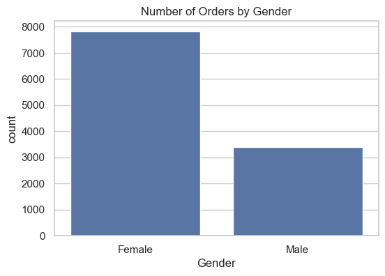

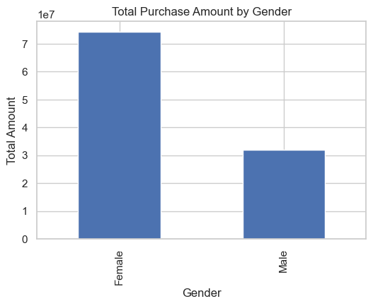

```
Total amount by gender:
 Gender
Female    74307682
Male      31871146
Name: Amount, dtype: Int64
```

```python
# Gender Analysis: number of orders and total purchase amount
import matplotlib.pyplot as plt
import seaborn as sns

# Count of orders by Gender
plt.figure(figsize=(6,4))
sns.countplot(data=df, x='Gender', order=df['Gender'].value_counts().index)
plt.title("Number of Orders by Gender")
plt.show()

# Total purchase amount by Gender
gender_amount = df.groupby('Gender')['Amount'].sum().sort_values(ascending=False)
plt.figure(figsize=(6,4))
gender_amount.plot(kind='bar')
plt.title("Total Purchase Amount by Gender")
plt.ylabel("Total Amount")
plt.show()

print("Total amount by gender:\n", gender_amount)
```

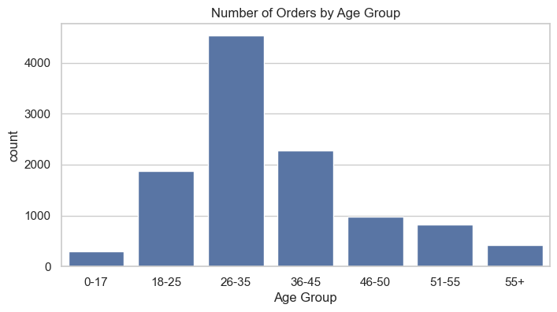

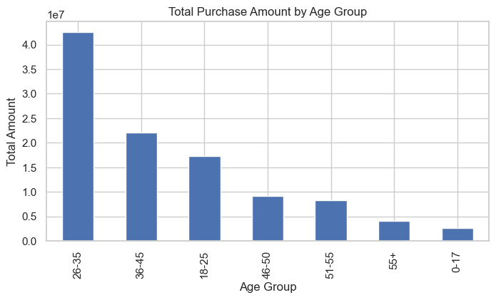

```
Total amount by Age Group:
 Age Group
26-35    42581768
36-45    22135137
18-25    17235530
46-50     9207844
51-55     8237909
55+       4080987
0-17      2699653
Name: Amount, dtype: Int64
```

```python
plt.figure(figsize=(8,4))
sns.countplot(data=df, x='Age Group', order=df['Age Group'].cat.categories)
plt.title("Number of Orders by Age Group")
plt.show()


age_amount = df.groupby('Age Group')['Amount'].sum().sort_values(ascending=False)
plt.figure(figsize=(8,4))
age_amount.plot(kind='bar')
plt.title("Total Purchase Amount by Age Group")
plt.ylabel("Total Amount")
plt.show()

print("Total amount by Age Group:\n", age_amount)
```

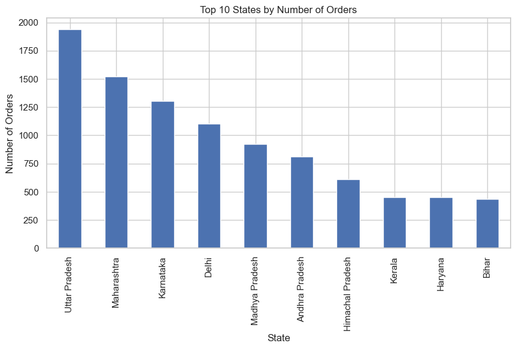

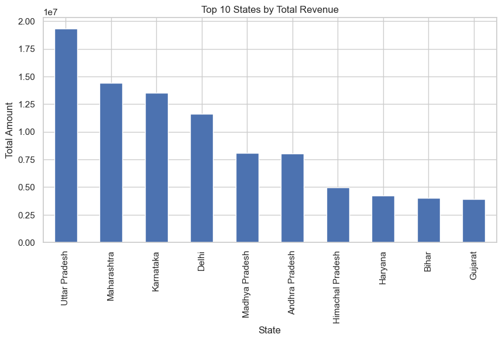

```
Top states by orders:
 State
Uttar Pradesh       1942
Maharashtra         1522
Karnataka           1304
Delhi               1104
Madhya Pradesh       921
Andhra Pradesh       811
Himachal Pradesh     608
Kerala               453
Haryana              451
Bihar                433
Name: count, dtype: int64
Top states by revenue:
 State
Uttar Pradesh       19346055
Maharashtra         14404467
Karnataka           13523540
Delhi               11603819
Madhya Pradesh       8101142
Andhra Pradesh       8037147
Himachal Pradesh     4963368
Haryana              4217871
Bihar                4014669
Gujarat              3938159
Name: Amount, dtype: Int64
```

```python
top_states_count = df['State'].value_counts().head(10)
plt.figure(figsize=(10,5))
top_states_count.plot(kind='bar')
plt.title("Top 10 States by Number of Orders")
plt.ylabel("Number of Orders")
plt.show()


top_states_amount = df.groupby('State')['Amount'].sum().sort_values(ascending=False).head(10)
plt.figure(figsize=(10,5))
top_states_amount.plot(kind='bar')
plt.title("Top 10 States by Total Revenue")
plt.ylabel("Total Amount")
plt.show()

print("Top states by orders:\n", top_states_count)
print("Top states by revenue:\n", top_states_amount)
```

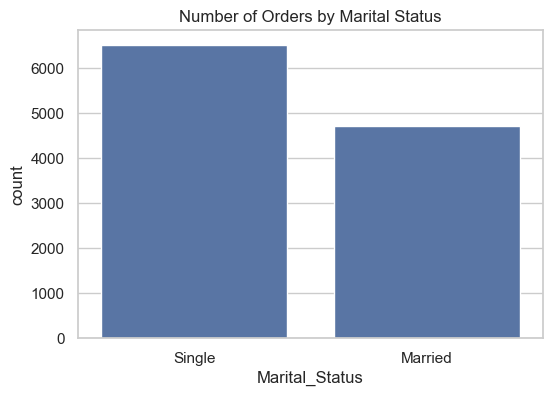

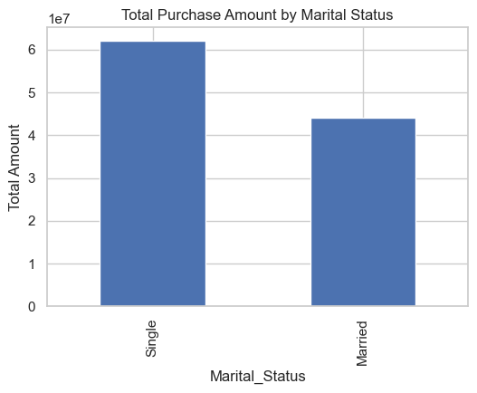

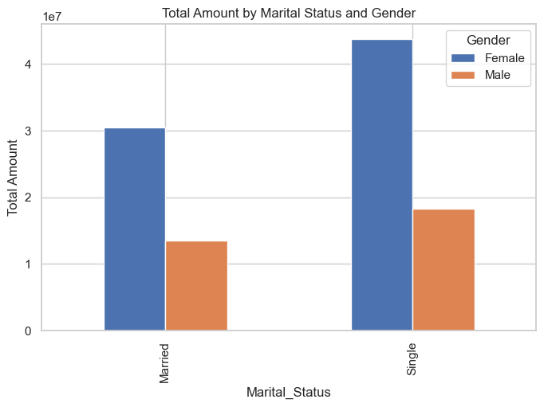

```
Total amount by Marital Status:
 Marital_Status
Single     62098736
Married    44080092
Name: Amount, dtype: Int64
```

```python
plt.figure(figsize=(6,4))
sns.countplot(data=df, x='Marital_Status', order=df['Marital_Status'].value_counts().index)
plt.title("Number of Orders by Marital Status")
plt.show()

marital_amount = df.groupby('Marital_Status')['Amount'].sum().sort_values(ascending=False)
plt.figure(figsize=(6,4))
marital_amount.plot(kind='bar')
plt.title("Total Purchase Amount by Marital Status")
plt.ylabel("Total Amount")
plt.show()


pivot = df.pivot_table(index='Marital_Status', columns='Gender', values='Amount', aggfunc='sum').fillna(0)
pivot.plot(kind='bar', figsize=(8,5))
plt.title("Total Amount by Marital Status and Gender")
plt.ylabel("Total Amount")
plt.show()

print("Total amount by Marital Status:\n", marital_amount)
```

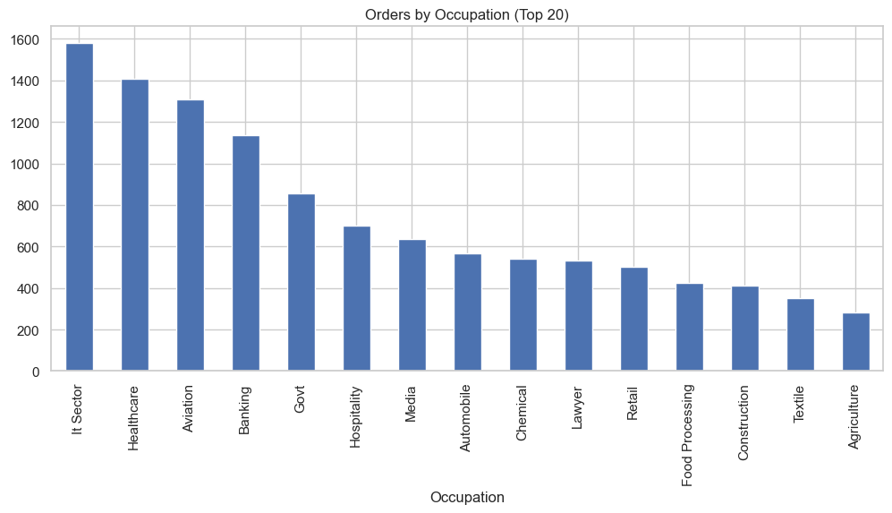

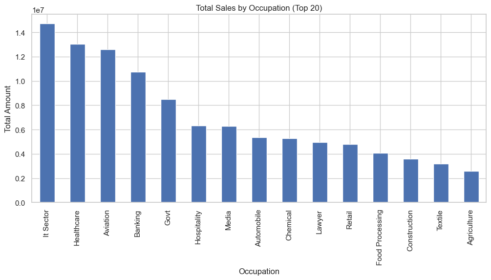

```
Top occupations by revenue:
 Occupation
It Sector          14741862
Healthcare         13034587
Aviation           12599994
Banking            10770611
Govt                8517212
Hospitality         6337633
Media               6295833
Automobile          5368596
Chemical            5297436
Lawyer              4981665
Retail              4783170
Food Processing     4070670
Construction        3589588
Textile             3204972
Agriculture         2584999
Name: Amount, dtype: Int64
```

```python
plt.figure(figsize=(12,5))
df['Occupation'].value_counts().head(20).plot(kind='bar')
plt.title("Orders by Occupation (Top 20)")
plt.show()


occ_amount = df.groupby('Occupation')['Amount'].sum().sort_values(ascending=False).head(20)
plt.figure(figsize=(12,5))
occ_amount.plot(kind='bar')
plt.title("Total Sales by Occupation (Top 20)")
plt.ylabel("Total Amount")
plt.show()

print("Top occupations by revenue:\n", occ_amount)
```

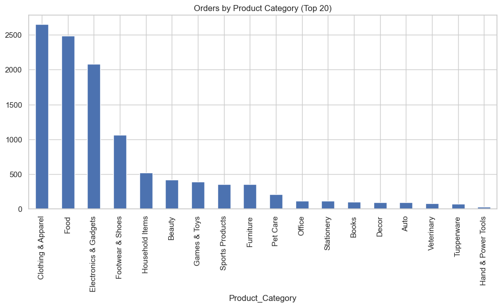

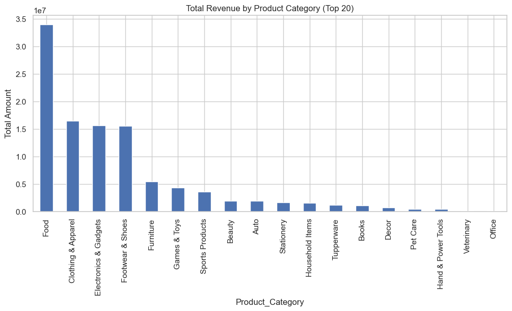

```
Top product categories by revenue:
 Product_Category
Food                     33933883
Clothing & Apparel       16484472
Electronics & Gadgets    15607657
Footwear & Shoes         15575209
Furniture                 5440052
Games & Toys              4331694
Sports Products           3635933
Beauty                    1959484
Auto                      1935042
Stationery                1676052
Household Items           1569337
Tupperware                1155642
Books                     1061478
Decor                      730360
Pet Care                   482277
Hand & Power Tools         405618
Veterinary                 112702
Office                      81936
Name: Amount, dtype: Int64
```

```python
plt.figure(figsize=(12,5))
df['Product_Category'].value_counts().head(20).plot(kind='bar')
plt.title("Orders by Product Category (Top 20)")
plt.show()


cat_amount = df.groupby('Product_Category')['Amount'].sum().sort_values(ascending=False).head(20)
plt.figure(figsize=(12,5))
cat_amount.plot(kind='bar')
plt.title("Total Revenue by Product Category (Top 20)")
plt.ylabel("Total Amount")
plt.show()

print("Top product categories by revenue:\n", cat_amount)
```

```python
pivot = df.pivot_table(
    index='Age Group',
    columns='Product_Category',
    values='Amount',
    aggfunc='sum',
    observed=False
).fillna(0)
```

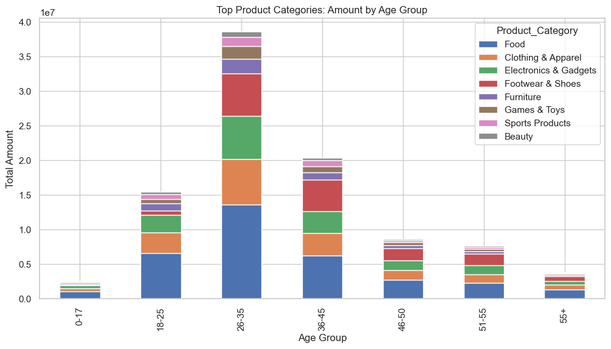

```python
pivot = df.pivot_table(index='Age Group', columns='Product_Category', values='Amount', aggfunc='sum').fillna(0)


top_cats = pivot.sum().sort_values(ascending=False).head(8).index
pivot[top_cats].plot(kind='bar', stacked=True, figsize=(12,6))
plt.title("Top Product Categories: Amount by Age Group")
plt.ylabel("Total Amount")
plt.show()
```

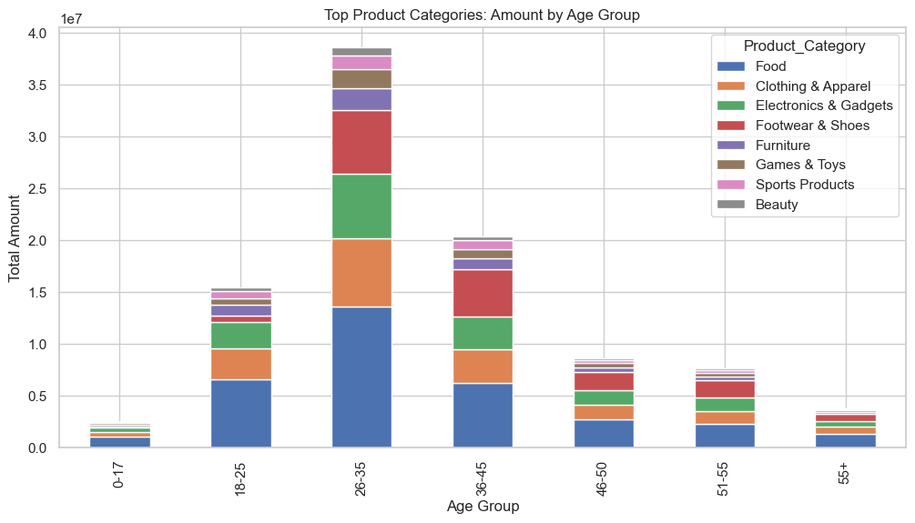

```python
top_cats = pivot.sum().sort_values(ascending=False).head(8).index
pivot[top_cats].plot(kind='bar', stacked=True, figsize=(12,6))
plt.title("Top Product Categories: Amount by Age Group")
plt.ylabel("Total Amount")
plt.show()
```

```python
pivot_occ = df.pivot_table(
    index='Occupation',
    columns='Product_Category',
    values='Amount',
    aggfunc='sum'
).fillna(0)
```

```python
pivot_occ = pivot_occ.apply(pd.to_numeric, errors='coerce').fillna(0)
```

```python
pivot_occ.dtypes
```

```
Product_Category
Auto                     Int64
Beauty                   Int64
Books                    Int64
Clothing & Apparel       Int64
Decor                    Int64
Electronics & Gadgets    Int64
Food                     Int64
Footwear & Shoes         Int64
Furniture                Int64
Games & Toys             Int64
Hand & Power Tools       Int64
Household Items          Int64
Office                   Int64
Pet Care                 Int64
Sports Products          Int64
Stationery               Int64
Tupperware               Int64
Veterinary               Int64
dtype: object
```

```python
pivot_occ = df.pivot_table(
    index='Occupation',
    columns='Product_Category',
    values='Amount',
    aggfunc='sum',
    observed=False
)
```

```python
pivot_occ.info()
```

```
<class 'pandas.core.frame.DataFrame'>
Index: 15 entries, Agriculture to Textile
Data columns (total 18 columns):
 #   Column                 Non-Null Count  Dtype
---  ------                 --------------  -----
 0   Auto                   15 non-null     Int64
 1   Beauty                 15 non-null     Int64
 2   Books                  15 non-null     Int64
 3   Clothing & Apparel     15 non-null     Int64
 4   Decor                  15 non-null     Int64
 5   Electronics & Gadgets  15 non-null     Int64
 6   Food                   15 non-null     Int64
 7   Footwear & Shoes       15 non-null     Int64
 8   Furniture              15 non-null     Int64
 9   Games & Toys           15 non-null     Int64
 10  Hand & Power Tools     15 non-null     Int64
 11  Household Items        15 non-null     Int64
 12  Office                 15 non-null     Int64
 13  Pet Care               15 non-null     Int64
 14  Sports Products        15 non-null     Int64
 15  Stationery             15 non-null     Int64
 16  Tupperware             15 non-null     Int64
 17  Veterinary             15 non-null     Int64
dtypes: Int64(18)
memory usage: 2.5+ KB
```

```python
pivot_occ_numeric = pivot_occ.apply(pd.to_numeric, errors='coerce')
```

```python
pivot_occ_numeric.info()
```

```
<class 'pandas.core.frame.DataFrame'>
Index: 15 entries, Agriculture to Textile
Data columns (total 18 columns):
 #   Column                 Non-Null Count  Dtype
---  ------                 --------------  -----
 0   Auto                   15 non-null     Int64
 1   Beauty                 15 non-null     Int64
 2   Books                  15 non-null     Int64
 3   Clothing & Apparel     15 non-null     Int64
 4   Decor                  15 non-null     Int64
 5   Electronics & Gadgets  15 non-null     Int64
 6   Food                   15 non-null     Int64
 7   Footwear & Shoes       15 non-null     Int64
 8   Furniture              15 non-null     Int64
 9   Games & Toys           15 non-null     Int64
 10  Hand & Power Tools     15 non-null     Int64
 11  Household Items        15 non-null     Int64
 12  Office                 15 non-null     Int64
 13  Pet Care               15 non-null     Int64
 14  Sports Products        15 non-null     Int64
 15  Stationery             15 non-null     Int64
 16  Tupperware             15 non-null     Int64
 17  Veterinary             15 non-null     Int64
dtypes: Int64(18)
memory usage: 2.5+ KB
```

```python
pivot_occ_numeric = pivot_occ.astype(float)
```

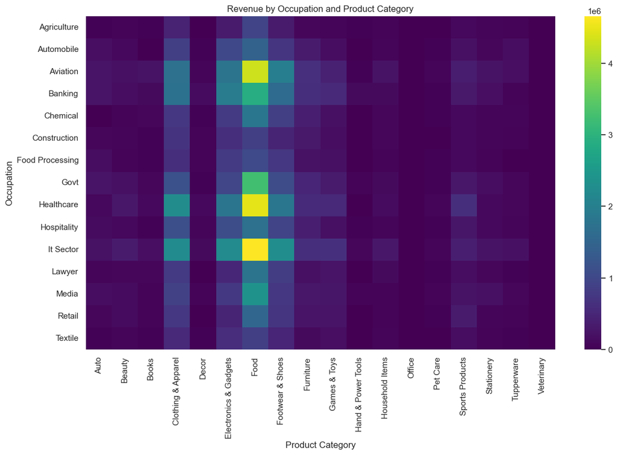

```python
plt.figure(figsize=(14,8))
sns.heatmap(pivot_occ_numeric, cmap='viridis')
plt.title("Revenue by Occupation and Product Category")
plt.xlabel("Product Category")
plt.ylabel("Occupation")
plt.show()
```

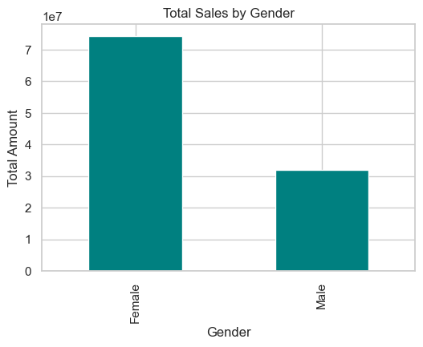

```python
plt.figure(figsize=(6,4))
df.groupby('Gender')['Amount'].sum().plot(kind='bar', color='teal')
plt.title("Total Sales by Gender")
plt.ylabel("Total Amount")
plt.show()
```

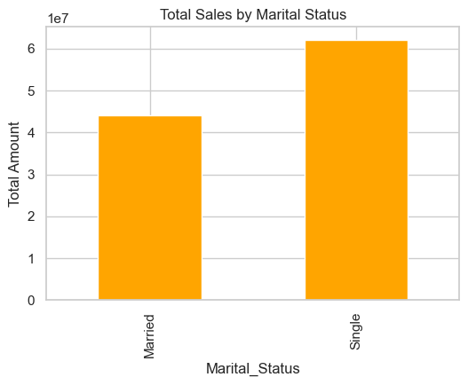

```python
plt.figure(figsize=(6,4))
df.groupby('Marital_Status')['Amount'].sum().plot(kind='bar', color='orange')
plt.title("Total Sales by Marital Status")
plt.ylabel("Total Amount")
plt.show()
```

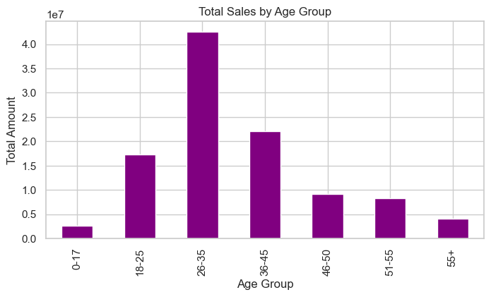

```python
plt.figure(figsize=(8,4))
df.groupby('Age Group')['Amount'].sum().plot(kind='bar', color='purple')
plt.title("Total Sales by Age Group")
plt.ylabel("Total Amount")
plt.show()
```

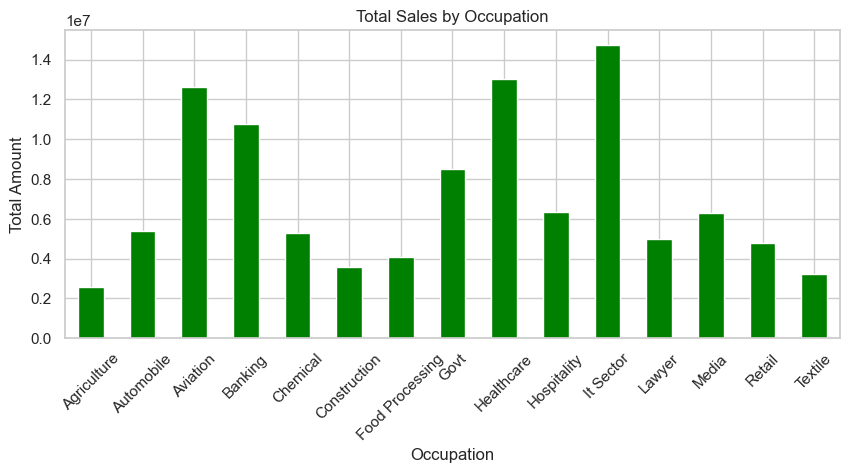

```python
plt.figure(figsize=(10,4))
df.groupby('Occupation')['Amount'].sum().plot(kind='bar', color='green')
plt.title("Total Sales by Occupation")
plt.ylabel("Total Amount")
plt.xticks(rotation=45)
plt.show()
```

Conclusion

The analysis of the New Year sales data shows that the highest revenue was generated by customers belonging to the age groups 26–35 and 36–45. These two groups appear to be the most active buyers in the dataset. Female customers have spent more than male customers overall. Single customers have also contributed more in terms of total spending compared to married customers.

Among various occupations, customers working in the IT sector, Healthcare, Aviation, and Banking contributed the highest sales amounts. This indicates that working professionals with higher disposable income are the primary contributors to sales revenue.

The product categories that produced the highest revenue were Food, Clothing and Apparel, Electronics and Gadgets, and Footwear and Shoes. These categories are the most preferred during seasonal and festival-based sales.

Overall, the New Year sale campaign reached a wide group of customers, mainly young working professionals, and generated strong revenue from lifestyle, fashion, and technology-oriented products.

Business Recommendations (Simple and Practical)

Marketing campaigns should be focused more on the 26–45 age group since they generate the highest spending.

Female customers and single individuals should be targeted with personalised offers and discounts.

High-income occupations such as IT, Healthcare, and Aviation should be targeted with premium product bundles.

More advertising and inventory planning should be directed towards high-performing states like Maharashtra, Karnataka, and Delhi.

Stock and promotions for categories such as Food, Clothing, and Electronics should be increased during major sale periods.